# Project Background

## 1 Mokelumne River System

moo-ka-la-mi

Mokelumne (“People of the Fish Net”) River runs 95-miles (153 km) in the Sierra Nevada Mountains (2,143 square miles (5,550 km<sup>2</sup>). The Upper Mokelumne River Basin and drains about 550 square miles (1,400 km<sup>2</sup>), or 25.7% of the total watershed.

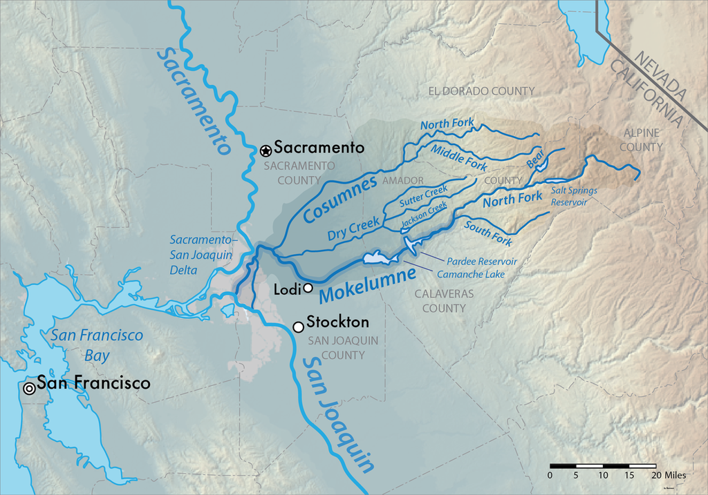

Map of the Mokelumne & Cosumnes Rivers in Central California, USA. Shaded relief and coastline from US Geological Survey.

### 1.1 Human modifications

- 1920: Upper Mokelumne River Hydro project (see Section 1.2)
- 1929: Pardee dam
- 1963: Camanche dam
- 1964: [Mokelumne River Fish Hatchery](https://en.wikipedia.org/wiki/Mokelumne_River_Fish_Hatchery) (below Camanche)
- Consumes River, the Mokelumne’s major tributary, is one of only a few Sierra rivers without large dams

### 1.3 Ecology & Biodiversity

The watershed features similar species composition, hydrologic regime, and topographic profiles to other western alpine watersheds in California. These three watersheds are located on the western slope of the Sierra Nevada Mountain Range and are therefore primarily fed by snow melt runoff accumulated from higher elevations.

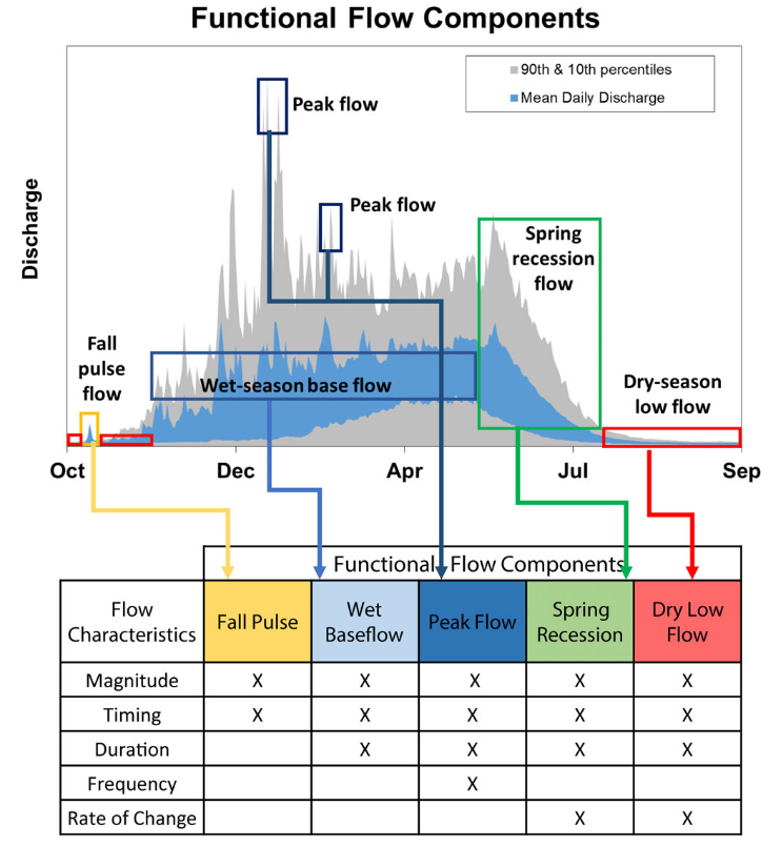

Functional flows and typical hydrograph for California rain-snowmelt systems. Form Yarnell et al. 2020

#### Salt Springs Reservoir

- owned by Pacific Gas and Electric (PG&E)
- 975 surface acre, 141,900 acre-foot storage capacity
- hydroelectric dam/reservoir (332 feet, 101 m) built in 1931, filled in 1951
- hotspot for wild trout fishing in Sierra Nevadas, but now supports warmwater fishery
- Fish present in 2012 survey: Sac pikeminnow, rainbows, green sunfish, Lahontan redside, Sac sucker

#### NF Mokelumne River (above dam)

- Rainbows. By July, however, the water flows greatly diminish and the fish are under considerable stress.

#### NF Mokelumne River (below dam)

- Flows on the river are heavily influenced by the dam upstream.
- Mostly small Browns and Rainbows 7-11 inches.

#### Bear reservoirs

- Lower Bear River Reservoir is a 727 acre lake. This is a deep lake where maximum depths are close to 200 feet near the dam and typical depths in the center of the lake are close to 100 feet.
- The lower lake is stocked with 13,000 rainbows and 7,200 Browns annually by DFG. The Bear River Resort adds 1000 lbs of trophy sized rainbows, 3-10 lbs., in early June and another 1000 lbs. in September. The upper lake is stocked with Kamloop Rainbow fingerlings.
- Lower Bear Reservoir gets most of the attention with all types of water activity including water skiing and sailing.

#### Cole Creek

- small, moderately fished creek with wild rainbows
- Most are in the 4-6 inch class.
- The creek is mostly pocket water with large boulders.
- Heavy runoff in early Spring and flows are quite thin by mid-July.

#### Fish

Mokelumne River provides habitat for Pacific salmon and steelhead trout spawning runs. Historical migration upstream of Pardee Dam, before a natural waterfall prevented further progress. Comanche Dam has blocked access to several miles of the highest quality habitat. The Lower Mokelumne River (below Camache) is home to at least 35 species of fish.

UC Davis CalFish database queries were done by GreenGen to identify native and non-native fish present currently and/or historically within these watersheds (Table 1):

Table 1: Fish species identified by GreenGen in study area.

| Common Name | Scientific Name | Origin |
| --- | --- | --- |
| Pacific Lamprey | Entosphenus tridentatus | Native |
| Delta Smelt | Hypomesus transpacificus | Native |
| Hardhead | Mylopharaodon conocephalus | Native |
| Sacramento Hitch | Lavinia exilicauda exilicauda | Native |
| Chinook Salmon (Central Valley spring run) | Onchorynchus tshawytscha pop. 6 | Native |
| Coastal Rainbow Trout (Steelhead) | Onchorynchus mykiss irrideus | Native |
| Central Valley Steelhead | Onchorynchus mykiss | Native |
| Lake Trout | Salvelinus namaycush | Nonnative |
| Black Bullhead | Ameiurus melas | Nonnative |
| Brown Bullhead | Ameiurus nebulosus | Nonnative |
| Golden Shiner | Notemigonus crysoleucas | Nonnative |
| Lahontan Redside | Richardsonius egregius | Native |
| Brown Trout | Salmo trutta | Nonnative |
| Central California Roach | Lavinia symmetricus symmetricus | Native |
| Brook Trout | Salvelinus fontinalis | Nonnative |
| Sockeye (Kokanee) Salmon | Onchorynchus nerka | Nonnative |
| Black Crappie | Pomoxis nigromaculatus | Nonnative |
| Channel Catfish | Ictalurus punctatus | Nonnative |
| Redear Sunfish | Lepomis microlophus | Nonnative |
| Riffle Sculpin | Cottus gulosus | Nonnative |
| Sacramento Pikeminnow | Ptychocheilus grandis | Native |
| Sacramento Sucker | Catostomus occidentalis occidentalis | Native |
| Smallmouth Bass | Micropterus dolomieu | Nonnative |
| Spotted Bass | Micropterus punctulatus | Nonnative |
| Threadfin Shad | Dorosoma petenence | Nonnative |
| White Catfish | Ameiurus catus | Nonnative |
| White Crappie | Pomoxis annularis | Nonnative |
| Lahontan Cutthroat Trout | Onchorynchus clarkii henshawi | Nonnative |

GreenGen ientified six special status fish species: Pacific Lamprey, Delta Smelt, Hardhead, Sacramento Hitch, Chinook salmon-central valley spring run, Steelhead (coastal rainbow trout).

Within the reservoirs and riverine features associated with implementation of the proposed Project, only two have potential to occur: **Sacramento hitch, and hardhead.**

*Oncorhynchus mykiss irideus*, occurs within Project watersheds as resident rainbow trout, but not as anadromous steelhead. Additional subspecies of rainbow trout are expected to occur from hatchery stocking operations.

Pacific lamprey, Delta smelt, and Chinook salmon do not exist in the Mokelumne River watershed above Camanche Dam.

Downstream of the immediate Project vicinity in the Lower Mokelumne River below Pardee and Camanche Reservoirs, primary aquatic species include Fall run chinook salmon, and federally threatened California Central Valley steelhead.

**Knowledge gaps:**

- effects of project on fish passage in watershed
- effects of project on aquatic recreational activities (fishing, boating, etc)
- effects of project on fish habitat and resources
- describe and quantify fish species, abundance, life stages, and depths of occurrence within the reservoirs and inform entrainment risk
- Characterization of the fish community, including special-status and non-native fish populations, as well as presence of whirling disease (Myxobolus cerebralis) within Project study limits
- Information regarding the locations and attributes of small-scale habitat features (e.g., springs/seeps, small streams, other unique plant communities)
- Current information on the location of special-status fish populations within the study area boundary
- Identification of species and life stages of fish present within Cole Creek, Bear River, Upper & Lower Bear Reservoirs, Salt Springs Reservoir, and North Fork Mokelumne River (above Salt Springs)
- Identification and assessment of habitat types within the FERC Project boundary, especially the locations of interest for surveying fish to determine the most effective and safe access and surveying approach
- Evaluation of whether potential Project construction or operation may have impacts on these species, including entrainment
- Studying both construction scenarios under consideration to inform the final Project design

**Identified Issues:**

- Modifications to the volume and timing in water flow and reservoir levels (seasonal or daily)
- Changes to habitat conditions (e.g., streambed characteristics) from modified flow regimes, including increased streambank erosion and sedimentation downstream of proposed Project
- Vegetation removal within the riparian corridor creates potential for increased water temperatures from loss of shade
- Loss of riparian habitat resulting in loss of protective cover and increased predation
- Exchange of fish species from different watersheds and elevations during operations
  - Entrainment of fish into Project facilities during operations, including potential intermixing of fish communities between reservoirs
  - currently lake trout in Bear Reservoir; CDFW do not want them entrained into Salt Springs Reservoir; fish screen would ovoid this
  - entrainment reduction and intake velocity requirements
- lake level change (Fluctuation of reservoir surface elevation from Project operations)
  - reservoir/spawning habitat for fish who wouldn’t otherwise have access to spawning habitat
- Changing water temperature and quality in affected stream reaches and water bodies and direct human disturbance related to Project operations and maintenance
- Changes to catch per unit effort and species composition for recreational anglers
- movement of pathogens: Whirling disease (Myxobolus cerebralis)

#### Amphibians and Reptiles

Table 2: Amphibian and reptile species identified by GreenGen in study area.

| Common Name | Scientific Name | Origin |
| --- | --- | --- |
| Yosemite toad | Anaxyrus canorus | Native |
| Foothill yellow-legged frog | Rana boylii | Native |
| Sierra Nevada yellow-legged frog | Rana sierrae | Native |
| Southern long-toed salamander | Ambystoma macrodactylum sigillatum | Native |
| Western pond turtle | Emys marmorata / Actinemys marmorata | Native |

Identified Issues

- surface level fluctuations / flow alterations can cause loss or degradation of breeding and/or foraging habitat
  - stranding or scouring or egg masses and larvae
- modified flow regimes, including increased streambank erosion and changes to sedimentation downstream of the proposed Project, could potentially impact habitat as well, causing decreased water quality for larvae and egg masses, and loss of bank habitat
- Changing water temperature and quality in affected stream reaches and water bodies could impact foraging and breeding habitat.
- Vegetation clearing, creation or improvement of access roads, digging and trenching, and other Project construction activity, operations and maintenance could result in temporary and permanent habitat loss.
- risk of increased disturbance and mortality from the increased traffic associated with operations and maintenance
- use of herbicides and vegetation maintenance equipment could impact amphibian reproduction or health
- Forest Service will have opinions re: foothill yellow-legged water temperature issues for release downstream of Salt Springs
- movement of pathogens (chytridiomycosis fungus *Batrachochytrium dendrobatidis* and *Ranavirus* spp.)

#### Benthic Macroinvertebrates

BMIs are an important food source for fisheries communities within the Project area as well as indicators of water quality and ecosystem health.

A BMI Study is proposed to establish a pre-Project baseline inventory of the BMI community.

Issues:

- Modifications to the volume and timing in water flow and reservoir levels (seasonal or daily) and transition from lentic to lotic ecosystem types
- Cycling of water between reservoirs may disrupt current disturbance regimes and may reduce habitat suitability for sensitive long-lived taxa (including EPT species) and increase habitat suitability for disturbance-resilient species (such as blackflies, worms and snails). Effects of disturbance regime shifts may disproportionately affect shoreline and shallow water habitats preferred by BMI species
- Changes to habitat conditions (e.g., streambed characteristics) from modified flow regimes, including increased streambank erosion and sedimentation downstream of proposed Project may impact aquatic life
- Changes in water chemistry could alter production, composition, and health of BMI community and affect fisheries communities
- Exchange of predator species (e.g., fish) from different watersheds and elevations during operations
- Changing water temperature and quality in affected stream reaches and water bodies and direct human disturbance related to Project operations and maintenance may impact aquatic life

## 2 Mokelumne Water Battery Project

### 2.1 Project description

By 2030, 60 percent of CA’s energy must come from renewable resources, and by 2045, 100 percent. But wind and solar are not available all the time.

The GreenGen Storage Mokelumne Water Battery Project will reduce California’s reliance on fossil fuels by meeting the state’s energy demands with reliable renewable energy. It takes advantage of two existing hydroelectric reservoirs in CA’s Sierra foothills, so few environmental impacts. Without pumped hydro, CA will have to rely on fossil fuels to integrate variable renewables (in 2018, CA curtailed ~ 460,000 MWh, enough to power 80,000 households).

The PSH Project is located within the Cole Creek, Bear River, Lower Bear Reservoir, and Salt Springs Reservoir – North Fork Mokelumne River watersheds. The proposed Project will involve the Salt Springs Reservoir and Lower Bear Reservoirs, all of which are on the Mokelumne River. Additionally, the proposed water conveyance tunnel alignments that will connect the Salt Springs and Bear Reservoirs, pass beneath Cole Creek, a tributary of the Mokelumne.

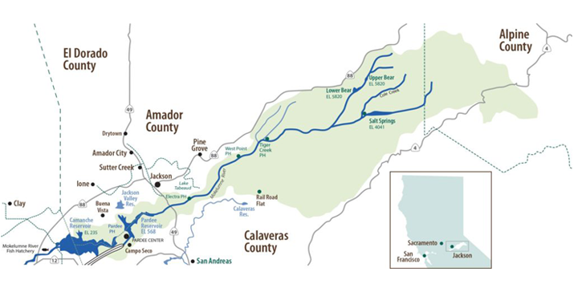

The Mokelumne Water Battery Project is located in the Sierra Nevada mountains, east of Sacramento, and about 33 miles east of Jackson, California. The project will pump water from the existing Salt Springs Reservoir up to the Lower Bear River Reservoir located on the Mokelumne River. The project will also include a water conveyance tunnel connecting the reservoirs, a powerhouse, transmission line, and other associated infrastructure (90% underground).

### 2.2 Key features

- 400 MW power capacity
- 4,000 MWh of energy capacity
- 2 reversible pump-turbines
- 8-10 hours of energy storage
- will move approx. 3,000 acre-feet of water back and forth

### 2.3 Benefits

- Provide carbon-free electricity, thereby reducing GHG emissions
- Meet the state’s energy and emissions goals
- Create hundreds of construction jobs and approximately ten permanent jobs
- Provide local economic stimulus throughout project development and operation

### 2.5 Environmental Impacts

“The project leaders have spent their careers working towards environmental causes and encouraging renewable energy. Project development will be guided by this deep commitment to respecting and protecting existing environments and resource use where possible, and to mitigating changes where needed. The project team pledges to work closely with environmental resource agencies and interested stakeholders to ensure that this commitment is met.”

- Designed to be an enhancement when constructed
- Already a stressed system (and CC will make it worse)
- Wild & Scenic River starts ½ mile downstream of Salt Springs but upstream of confluence of Mokelumne and Bear
- Model water temperature and downstream impacts from proposed operations and downstream effects
- Using Lower Bear (fewer impacts to cultural/bio resources and no new roads)
- No dam raises (no new inundation)
  - footprint is 53 acres, all FS land
  - 90% of facilities are underground
- 3,000 acre-feet of water back and forth (impacts on shore line)

### 2.6 Water rights

- reservoir goes low – if they can store more water in Lower Bear, they may be able to operate project yearlong

## 3 Relevant Groups

**Clean Energy Ministerial ([CEM](https://www.cleanenergyministerial.org/))**

- high-level global forum to promote policies and programmes that advance clean energy technology, to share lessons learned and best practices, and to encourage the transition to a global clean energy economy

**U.S. Energy Information Administration (EIA)**

- independent statistics and analysis of energy markets and trends
- Battery Storage in the United States: [An Update on Market Trends](https://www.eia.gov/analysis/studies/electricity/batterystorage/)
- [explainer](https://www.eia.gov/energyexplained/electricity/energy-storage-for-electricity-generation.php) on electricity and energy storage

**Global Energy Monitor ([GEM](https://globalenergymonitor.org/))**

- develop and share information in support of the movement for clean energy
- many trackers, including the [Hydropower tracker](https://globalenergymonitor.org/projects/global-hydropower-tracker/)

**Global Energy Storage Database ([DOE](https://sandia.gov/ess-ssl/gesdb/public/))**

- research-grade information on grid-connected energy storage projects and relevant state and federal policies

**Global Renewables Alliance ([GRA](https://globalrenewablesalliance.org/))**

**National Hydropower Association ([NHA](https://www.hydro.org/))**

- nonprofit association dedicated exclusively to promoting the growth of clean, renewable hydropower and marine energy

**International Hydropower Association ([IHA](https://www.hydropower.org/))**

- “The global voice for sustainable hydropower”
- 2023 World Hydropower Congress, Bali, Indonesia, 31 Oct - 2 Nov

**International Energy Agency (IEA)**

- 2023 tracking clean energy [progress report](https://www.iea.org/reports/tracking-clean-energy-progress-2023)

**International Forum on PSH ([IFPSH](https://pumped-storage-forum.hydropower.org/))**

- government-led multi-stakeholder platform to shape and enhance the role of pumped storage hydropower in future power systems
- created Nov 2020 chaired by US DOE

**International Renewable Energy Agency ([IRENA](https://www.irena.org/))**

- intergovernmental organization mandated to facilitate cooperation, advance knowledge, and promote the adoption and sustainable use of renewable energy

**United Nations (UN)**

- “Peace, dignity, and equality on a healthy planet”
- intergovernmental organization whose stated purposes are to maintain international peace and security, develop friendly relations among nations, achieve international cooperation, and serve as a center for harmonizing the actions of nations
- COP28 - 2023 Conference of the Parties to the UN Framework Convention on Climate Change, Dubai, UAE

**US DOE Water Power Technologies Office (WPTO)**

- does R&D to understand and assess value of potential benefits of existing and prospective PSH (e.g., the [HydroWIRES Initiative](https://www.energy.gov/eere/water/hydrowires-initiative) for grid reliability, resilience, and integration).

## 4 Glossary

**Curtailment**: when the sun shines and the wind blows *more than* is demanded, a system operator deliberately reduces the supply of electricity in order to balance the grid. Where storage does not exist, this means that renewable electricity is wasted and not stored for potential use in future

**Electricity generation / production:** how much electricity produced over time (while demand is determined by when you use it), measured in watthours (kWh)

**Electricity demand**: how much electricity is being used at any given time; measured in watthours (kWh); demand ebbs and flows over short and long time spans

**Evaporation suppressors**: small plastic objects floated on a reservoir to reduce wind speeds and evaporation rates

**Power capacity**: the maximum instantaneous amount of electric power that can be generated on a continuous basis and is measured in units of watts (kilowatts [kW], megawatts [MW], or gigawatts [GW]); utility-scale are at least 1 MW

**Energy capacity**: the total amount of energy that can be stored in or discharged from the storage system; measured in units of watthours (kilowatthours [kWh], megawatthours [MWh], or gigawatthours [GWh])

**Hydraulic Head**: measures the amount of mechanical energy available in water in a river, stream or even lake; equivalent to the water level in a static (non-flowing) water body

**Load**: electricity demand

**Variable energy**: power output rises and falls in response to, e.g., sun and wind

**Lumen**: (symbol: **lm**) SI unit of luminous flux, a measure of the total quantity of visible light emitted by a source per unit of time (brightness); Luminous flux differs from power (radiant flux) in that radiant flux includes all electromagnetic waves emitted, while luminous flux is weighted according to a model (a “luminosity function”) of the human eye’s sensitivity to various wavelengths

**Joule**: SI unit of energy; It is equal to the amount of work done when a force of 1 newton displaces a mass through a distance of 1 metre in the direction of the force applied. It is also the energy dissipated as heat when an electric current of one ampere passes through a resistance of one ohm for one second.

**Watt:** (symbol: W) SI unit of power or radiant flux, equal to 1 joule per second or 1 kg⋅m<sup>2</sup>⋅s<sup>−3</sup>. It is used to quantify the rate of energy transfer.

## 5 References